# Extract cell-cell communication knowledge for RaCInG

## Knowledge extracted from literature

| Resource | Data | Reference |
| --- | --- | --- |
| Omnipath & Liana | Inter-cellular interactions | Türei et al. Molecular systems biology, 2021; Dimitrov et al. Nat Commun, 2022 |
| Ramilowski | RNA-seq data from 144 cell types | Ramilowski et al., Nat Commun, 2015 |
| In silico deconvolution | Quantification of individual cell-type abundance | quanTIseq, EPIC, ConsensusTME, xCell, TIMER, and MCP-counter |
| Cancer Cell Line Encyclopedia | Cancer cell expressed L-R interactions | Barretina et al., Nat, 2012 |

## Curated cell-cell communication interactions

> Using LIANA (`liana` R package version 0.1.10), we retrieve a customized set of intercellular interactions from OmniPath (`OmniPathR` R package version 3.7.0)
- This set includedg expert-curated (in the context of CCC) interactions from “CellPhoneDB”, “CellChatDB”, “ICELLNET”, “connectomeDB2020”, “CellTalkDB” and “Cellinker” resources.

```r
# Retrieve consensus resource, curated  (in the context of CCC) ligand-receptor interactions
curated_omni <- liana::get_curated_omni() # returns, via OmniPath, the most up-to-date version of all databases.
```

[output not shown]

```r
#curated_omni <- select_resource("Consensus")[[1]] #  retrieves the network stored by the developers.

# Remove interactions from ECM
curated_omni <- curated_omni %>%
  filter(category_intercell_source %in% c("cell_surface_ligand", "ligand") &
           category_intercell_target %in% c("receptor", "adhesion"))

## Decomplexify (or split all complexes into subunits)
curated_omni <- curated_omni %>%
  liana::decomplexify(columns = c("source_genesymbol", "target_genesymbol"))

# Ligand-receptor pairs
LRpairs_curated <- unique(paste0(curated_omni$source_genesymbol, "_", curated_omni$target_genesymbol))

# Final knowledge data.frame
intercell_knowledge <- curated_omni
```

## Cell type fractions quantification

> Retrieve cell types that can be quantified from deconvolution of RNA-seq data
- We used a consensus approach based on six deconvolution methods accessible through the immunedeconv (`immunedeconv` R package version 2.1.0): “quanTIseq”, “EPIC”, “ConsensusTME”, “xCell”, “TIMER”, and “MCP-counter”.
- We considered the following cell types:
  - Dendritic cells (DC)
  - CD8+ T cells (CD8+ T)
  - Regulatory T cells (Treg)
  - B cells (B)
  - M1 macrophages (M1)
  - M2 macrophages (M2)
  - Healthy endothelial cells (Endo)
  - Cancer-associated firoblasts (CAF)
  - Natural Killer cells (NK)
  - Tumor cells (Tumor)
- Cell-type distribution in TCGA SKCM cancer type:

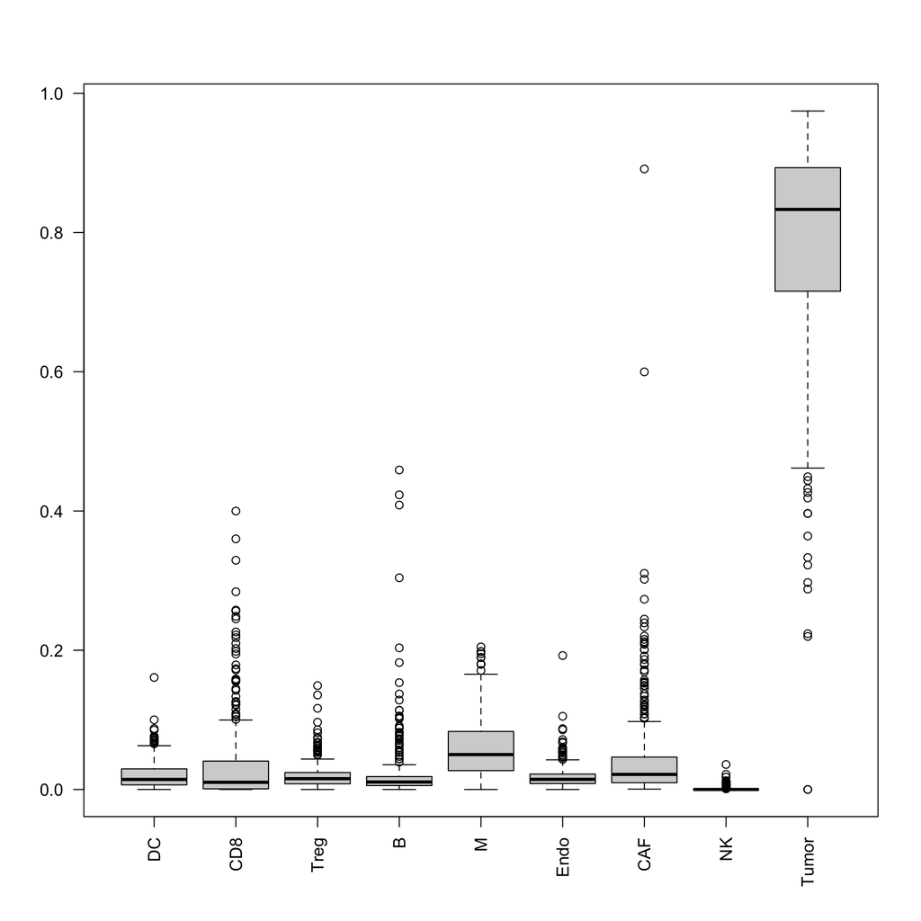

## Ramilowski CAGE expression data for human protein-coding genes in the 144 human primary cells

> Retrieve Ramilowski gene expression data
- We match the quantified cell types with cell types from Ramilowski
- Matching cell types (*double check why Maisa consider this aggregation*):
  - Dendritic cells (DC): Dendritic.Monocyte.Immature.derived, Dendritic.Plasmacytoid
  - CD8+ T cells (CD8+ T): CD8..T.cells
  - Regulatory T cells (Treg): CD4.CD25.CD45RA..naive.regulatory.T.cells, CD4.CD25.CD45RA..memory.regulatory.T.cells
  - B cells (B): CD19..B.cells
  - M1 macrophages (M1): Macrophage.Monocyte.derived
  - M2 macrophages (M2): Macrophage.Monocyte.derived
  - Healthy endothelial cells (Endo): Endothelial.Lymphatic, Endothelial.Microvascular
  - Cancer-associated firoblasts (CAF): Fibroblast.Lymphatic, Fibroblast.Skin.Normal
  - Natural Killer cells (NK): NK.cells
  - Tumor cells (Tumor): from Cancer Cell Lines

```
#>       Adipocyte.Breast Adipocyte.Omental Adipocyte.Perirenal
#> A1BG         36.847145         35.173724            49.72330
#> A1CF          0.000000          0.000000             0.00000
#> GGACT         3.357693          5.300857             6.10637
#>       Adipocyte.Subcutaneous Alveolar.Epithelial
#> A1BG               41.075959            4.142741
#> A1CF                0.000000            0.000000
#> GGACT               4.743955            7.056813
#>         CD19..B.cells CD4.CD25.CD45RA..naive.regulatory.T.cells
#> Min.         0.000000                                  0.000000
#> 1st Qu.      0.000000                                  0.000000
#> Median       5.792058                                  5.114767
#> Mean        39.434154                                 39.413974
#> 3rd Qu.     27.100837                                 27.004887
#> Max.     15772.289537                              15141.376045
#>         CD4.CD25.CD45RA..memory.regulatory.T.cells CD8..T.cells
#> Min.                                  0.000000e+00 0.000000e+00
#> 1st Qu.                               1.856841e-02 1.368865e-02
#> Median                                5.342468e+00 5.964291e+00
#> Mean                                  3.834758e+01 3.584734e+01
#> 3rd Qu.                               2.619446e+01 2.744884e+01
#> Max.                                  1.882948e+04 1.428095e+04
#>         Dendritic.Monocyte.Immature.derived Dendritic.Plasmacytoid
#> Min.                           0.000000e+00               0.000000
#> 1st Qu.                        4.431932e-02               0.000000
#> Median                         5.791021e+00               4.512443
#> Mean                           4.367726e+01              37.394240
#> 3rd Qu.                        2.687707e+01              25.686894
#> Max.                           2.937533e+04           11374.955003
#>         Endothelial.Lymphatic Endothelial.Microvascular Fibroblast.Lymphatic
#> Min.                 0.000000              0.000000e+00             0.000000
#> 1st Qu.              0.000000              8.135402e-02             0.000000
#> Median               6.961059              5.978561e+00             4.071949
#> Mean                33.622436              4.299490e+01            56.236479
#> 3rd Qu.             27.010782              2.439401e+01            23.090228
#> Max.              4917.338885              1.045393e+04         32069.987145
#>         Fibroblast.Skin.Normal Macrophage.Monocyte.derived    NK.cells
#> Min.              0.000000e+00                    0.000000    0.000000
#> 1st Qu.           4.871850e-02                    0.000000    0.000000
#> Median            6.521185e+00                    6.592899    5.713957
#> Mean              4.242650e+01                   47.860841   36.019624
#> 3rd Qu.           2.516538e+01                   28.124109   28.089719
#> Max.              1.393698e+04                45970.814204 9196.098111
```

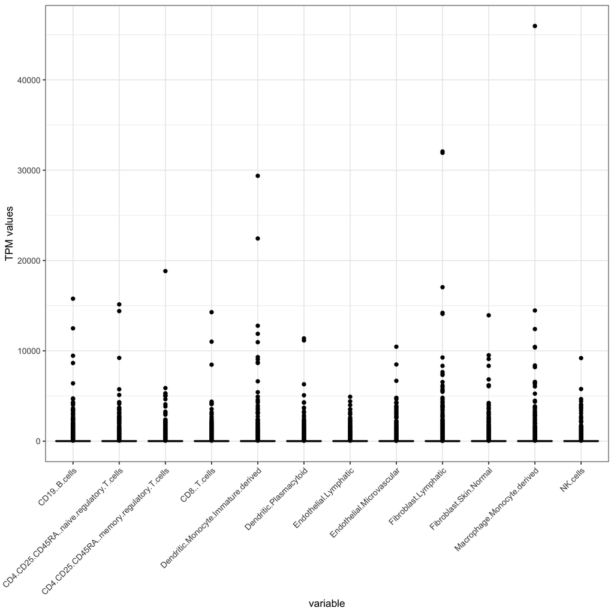

> Gene re-annotation: update of gene names
- Re-annotation is often useful when cross-matching genes across different data sources (i.e. Ramilowski and CCLE)
- We annotated gene names according to HUGO Gene Nomenclature Comittee (HGNC).

## Add tumor cell type using gene expression data from cancer cell lines (CCLE)

- We considered a pan-cancer cell type derived using data from the CCLE.
- We selected gene expression data for all cell lines linked to 18 solid cancer types, leaving 583 cell lines.
- We determined the median expression of each gene over all selected cell lines, which we considered as the gene expression of the pan-cancer cell type.
- According to Maisa’s report, the 10 TPM threshold to consider a gene expressed was also applicable on the CCLE data.

```
#> Number of activated genes in tumor cell type:  199
```

> Current gene expression matrix:

```
#> Number of genes =  17266
#> Number of cell types =  13
```

> Keep genes expressed if ≥10 TPM in at least one cell type

```
#> Genes ≥10 TPM:  11371
#> Genes <10 TPM:  5895
#>         CD19..B.cells CD4.CD25.CD45RA..naive.regulatory.T.cells
#> Min.         0.000000                                  0.000000
#> 1st Qu.      5.360244                                  4.378283
#> Median      18.370516                                 17.877671
#> Mean        59.522002                                 59.511870
#> 3rd Qu.     42.011704                                 41.262035
#> Max.     15772.289537                              15141.376045
#>         CD4.CD25.CD45RA..memory.regulatory.T.cells CD8..T.cells
#> Min.                                      0.000000     0.000000
#> 1st Qu.                                   5.008811     5.776172
#> Median                                   17.452239    18.713844
#> Mean                                     57.914041    54.094283
#> 3rd Qu.                                  40.221716    41.473391
#> Max.                                  18829.477271 14280.948145
#>         Dendritic.Monocyte.Immature.derived Dendritic.Plasmacytoid
#> Min.                               0.000000               0.000000
#> 1st Qu.                            5.718324               4.252153
#> Median                            17.725466              16.032732
#> Mean                              66.028455              56.525909
#> 3rd Qu.                           44.001603              42.870340
#> Max.                           29375.333009           11374.955003
#>         Endothelial.Lymphatic Endothelial.Microvascular Fibroblast.Lymphatic
#> Min.                 0.000000                  0.000000             0.000000
#> 1st Qu.              6.971247                  5.840122             3.616868
#> Median              18.376932                 16.568041            13.485317
#> Mean                50.680318                 64.915288            85.031276
#> 3rd Qu.             42.782210                 40.901777            43.677843
#> Max.              4917.338885              10453.928162         32069.987145
#>         Fibroblast.Skin.Normal Macrophage.Monocyte.derived    NK.cells
#> Min.                   0.00000                    0.000000    0.000000
#> 1st Qu.                6.35915                    6.592049    5.484861
#> Median                17.02581                   18.570065   18.498448
#> Mean                  63.98884                   72.336364   54.352714
#> 3rd Qu.               41.32135                   46.318341   45.004646
#> Max.               13936.98057                45970.814204 9196.098111
#>               Tumor
#> Min.       0.000000
#> 1st Qu.    0.000000
#> Median     0.000000
#> Mean       2.202496
#> 3rd Qu.    0.000000
#> Max.    2231.700000
```

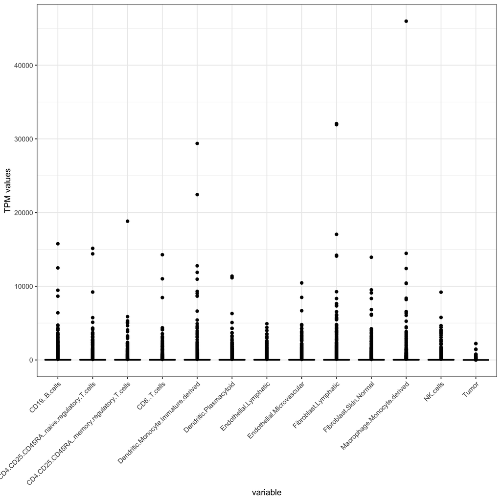

> Exclude those ligands and receptors that were expressed by a cell type but not paired to another ligand or receptor in the cell network.

```r
pairs_to_keep <- NULL
for (ii in 1:nrow(intercell_knowledge)){
  receptor <- intercell_knowledge[ii, "target_genesymbol"]
  ligand <- intercell_knowledge[ii, "source_genesymbol"]

  if (all(receptor %in% rownames(Expr_genes) & ligand %in% rownames(Expr_genes))){
    pairs_to_keep <- c(pairs_to_keep, ii)
  }else {
    next
  }
}
intercell_knowledge <- intercell_knowledge[pairs_to_keep, ]
receptors <- intercell_knowledge$target_genesymbol %>% unique()
ligands <- intercell_knowledge$source_genesymbol %>% unique()

# List of LRpairs
LR_pairs <- paste0(intercell_knowledge$source_genesymbol, "_", intercell_knowledge$target_genesymbol)
cat("Ligand-Receptor pairs available: ", length(LR_pairs))
```

```
#> Ligand-Receptor pairs available:  1234
```

```r
# Update gene expression matrix
Expr_genes <- Expr_genes[unique(c(ligands, receptors)), ]
```

## Investigate Ligand-Receptor pairs expression when aggregating cell types

- We aggregate cell types to keep only our defined set of cells, however we find cases in which quanTIseq cell type corresponds to more than one Ramilowski cell type.
- An example: “CAF” (quanTIseq) correspond to “Fibroblast.Lymphatic” and “Fibroblast.Skin.Normal” (Ramilowski).
- Also on L-R alone

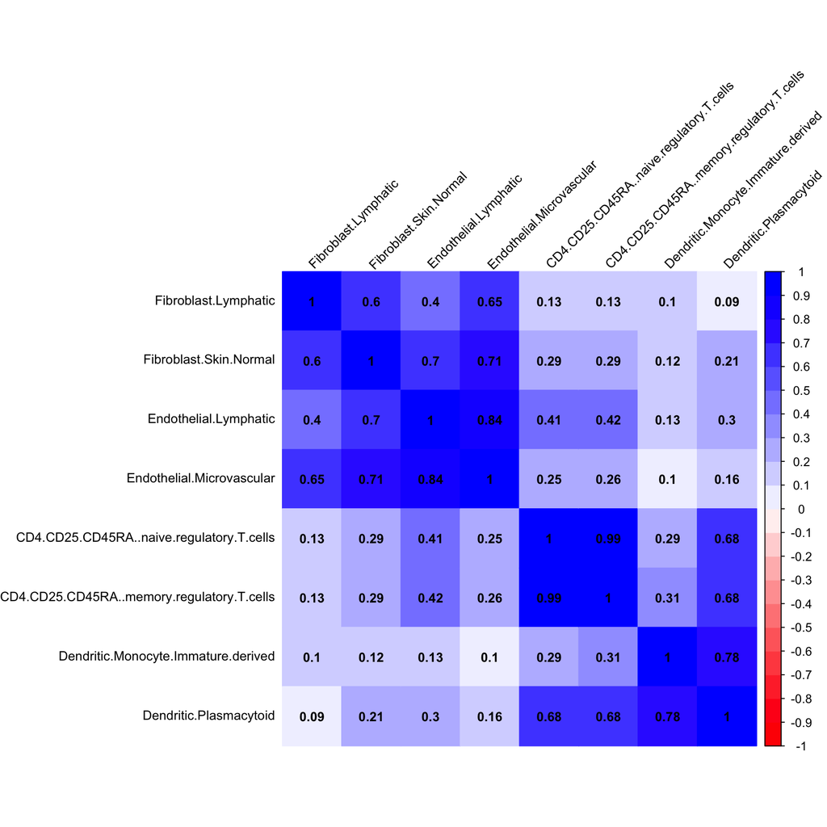

> Aggregation of cell types: match cell types from quantiseq with ramilowski
- This aggregation was based on Maisa’s externship report.
- We average cell types matching more than one ramilowski cell type

## Build cell-cell communication (ccc) intermediate table

> Each sender cell type and its ligand, each receiver cell type and its receptor, both with their corresponding expression.

```r
ccc_table <- do.call(rbind, lapply(colnames(RNA_expr), function(cell_type){
  ccc_table <- do.call(rbind, lapply(1:length(LR_pairs), function(LR_pos){

    L <- sapply(strsplit(LR_pairs[LR_pos], split = "_"), head, 1)
    R <- sapply(strsplit(LR_pairs[LR_pos], split = "_"), tail, 1)

    tmp_table <- data.frame(Sender = cell_type,
                            Ligand = L,
                            Expr_Ligand = as.numeric(RNA_expr[L,cell_type]),
                            Receiver = colnames(RNA_expr),
                            Receptor = R,
                            Expr_Receptor= as.numeric(RNA_expr[R,]))

    return(tmp_table)
  }))
  return(ccc_table)
}))

connections_cell_type <- aggregate(Ligand ~ Sender + Receiver , data = ccc_table, FUN = "length")
colnames(connections_cell_type)[3] <- "n_connections"

cat("Head cell-cell communication network: \n")
```

```
#> Head cell-cell communication network:
```

```r
head(ccc_table)
```

```
#>   Sender Ligand Expr_Ligand Receiver Receptor Expr_Receptor
#> 1   Treg LGALS9    59.03374     Treg    PTPRC      823.7706
#> 2   Treg LGALS9    59.03374       DC    PTPRC      231.5985
#> 3   Treg LGALS9    59.03374     Endo    PTPRC        0.0000
#> 4   Treg LGALS9    59.03374      CAF    PTPRC        0.0000
#> 5   Treg LGALS9    59.03374        B    PTPRC      681.8022
#> 6   Treg LGALS9    59.03374   CD8+ T    PTPRC      901.0523
```

```r
cat("Number of total connections: ", nrow(ccc_table))
```

```
#> Number of total connections:  99954
```

> Apply 10 TPM threshold to resemble expressed pairs (L >= 10, R >= 10)

```r
# only pairs where both ligand and receptor have TPM >= 10 are kept (expressed pairs)
ccc_table_filtered <- ccc_table[ccc_table$Expr_Ligand >= 10 & ccc_table$Expr_Receptor >= 10, ]
cat("Head cell-cell communication network (>= 10 TPM): \n")
```

```
#> Head cell-cell communication network (>= 10 TPM):
```

```r
head(ccc_table_filtered)
```

```
#>   Sender Ligand Expr_Ligand Receiver Receptor Expr_Receptor
#> 1   Treg LGALS9    59.03374     Treg    PTPRC      823.7706
#> 2   Treg LGALS9    59.03374       DC    PTPRC      231.5985
#> 5   Treg LGALS9    59.03374        B    PTPRC      681.8022
#> 6   Treg LGALS9    59.03374   CD8+ T    PTPRC      901.0523
#> 7   Treg LGALS9    59.03374        M    PTPRC      338.8129
#> 8   Treg LGALS9    59.03374       NK    PTPRC      702.0901
```

```r
cat("Number of connections (TPM >= 10): ", nrow(ccc_table_filtered))
```

```
#> Number of connections (TPM >= 10):  15316
```

```r
# new list of LRpairs
LR_pairs <- unique(paste0(ccc_table_filtered$Ligand, "_", ccc_table_filtered$Receptor))
cat("Ligand-Receptor pairs available (TPM>=10): ", length(LR_pairs))
```

```
#> Ligand-Receptor pairs available (TPM>=10):  971
```

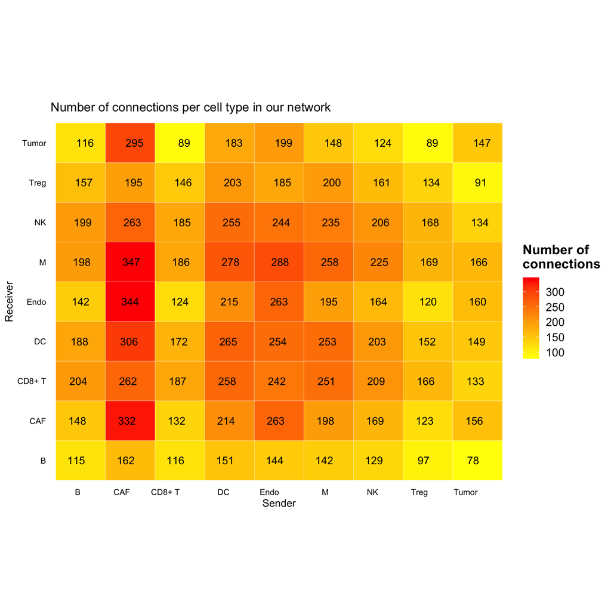

```r
# counting connections per cell type
connections_cell_type <- aggregate(Ligand ~ Sender + Receiver , data = ccc_table_filtered, FUN = "length")
colnames(connections_cell_type)[3] <- "n_connections"

# heatmap plot
ggplot(connections_cell_type ,aes(x = Sender, y = Receiver, fill = n_connections)) +
  geom_tile(color = "white", size = .1) +
  scale_fill_gradient(low = "yellow", high = "red", na.value = NA, name = "Number of \nconnections")+
  theme_minimal() +
  geom_text(aes(label= n_connections), stat = "identity", color="black",
            size = 4, angle = 0, position = position_dodge(0.2)) +
  ggplot2::coord_fixed(0.8) +
  theme(panel.grid = element_blank(), axis.text.x = element_text(angle = 0, hjust = 1, color = "black"),
        axis.text.y = element_text(angle = 0, hjust = 1, color = "black"),
                legend.position = "right", legend.direction = "vertical",
                 legend.text=element_text(size=12, angle = 0, hjust = 0.8),
                 legend.title = element_text(size =14, face = "bold", vjust = .9)) +
  labs(title = "Number of connections per cell type in our network")
```

> Export tables into excel files

## Obtain input data tables required for Model 1

### Ligands vs cell types compatibility

```r
ccc <- ccc_table_filtered
celltypes <- intersect(ccc$Sender %>% unique(), ccc$Receiver %>% unique())
ligands <- ccc$Ligand %>% unique()

celltype_L <- matrix(0, nrow = length(celltypes), ncol = length(ligands))
rownames(celltype_L) <- celltypes
colnames(celltype_L) <- ligands

for (CellType in celltypes){
  # filter for cell type and unique ligands
  tmp_celltype_L <- ccc %>%
    filter(Sender == CellType) %>%
    select(Ligand) %>% unique()
  # index matching ligands
  idx <- names(celltype_L[CellType, ]) %in% tmp_celltype_L$Ligand
  # set to 1
  celltype_L[CellType, idx] <- 1
}

cat("Ligand-celltype compatibility: IFNG \n")
```

```
#> Ligand-celltype compatibility: IFNG
```

```r
celltype_L[, "IFNG"]
```

```
#>   Treg     DC   Endo    CAF      B CD8+ T      M     NK  Tumor
#>      0      0      0      0      0      1      0      1      0
```

```r
# export table to excel file
#write.csv(celltype_L, file= file.path(path_to_output, "celltype_ligand.csv"), row.names = TRUE)
```

### Receptors vs cell-types compatibility

```r
receptors <- ccc$Receptor %>% unique()
celltype_R <- matrix(0, nrow = length(celltypes), ncol = length(receptors))
rownames(celltype_R) <- celltypes
colnames(celltype_R) <- receptors

for (CellType in celltypes){
  # filter for cell type and unique ligands
  tmp_celltype_R <- ccc %>%
    filter(Receiver == CellType) %>%
    select(Receptor) %>% unique()
  # index matching ligands
  idx <- names(celltype_R[CellType, ]) %in% tmp_celltype_R$Receptor
  # set to 1
  celltype_R[CellType, idx] <- 1
}

cat("Receptor-celltype compatibility: IFNGR1 \n")
```

```
#> Receptor-celltype compatibility: IFNGR1
```

```r
celltype_R[, "IFNGR1"]
```

```
#>   Treg     DC   Endo    CAF      B CD8+ T      M     NK  Tumor
#>      1      1      1      1      1      1      1      1      1
```

```r
cat("Receptor-celltype compatibility: IFNGR2 \n")
```

```
#> Receptor-celltype compatibility: IFNGR2
```

```r
celltype_R[, "IFNGR2"]
```

```
#>   Treg     DC   Endo    CAF      B CD8+ T      M     NK  Tumor
#>      1      1      1      1      1      1      1      1      1
```

```r
# export table to excel file
#write.csv(celltype_R, file= file.path(path_to_output, "celltype_receptor.csv"), row.names = TRUE)
```